# Difference-in-Difference

Card-Krueger (AER, 1994)

Takuya Shimamura

2021-07-01

**パッケージの読み込み** (Rのみ)

```r
library(tidyverse)    # data manipulation
library(stargazer)    # summarize data
library(foreign)      # read '.dta' file (Stat ver.15~)
```

**データの読み込み**

```
#--- Stat ver. ---#

** recode log
log using lec_multiple_regression.log, replace

** do not pause for -more- message
set more off

** set current directory
cd "Z:XXXXXX"

** read data
use "minimum_wage_data_v11.dta", clear
```

```r
#--- R ver. ---#
df <- read.dta("./00_Input/minimum_wage_data_v11.dta")
df %>% as.tibble()  ## `tibble` is better to look than `data.frame`
```

```
## # A tibble: 405 x 8
##    sheet chain co_owned state wage_st0 wage_st1  fte0  fte1
##    <int> <int>    <int> <fct>    <dbl>    <dbl> <dbl> <dbl>
##  1     1     1        0 NJ        4.5      5.05  35    44
##  2     2     1        0 NJ        4.75     5.25  16    15.5
##  3     3     2        0 NJ        4.25     5.05  15.5  10.5
##  4     4     3        0 NJ        4.75     5.05  19    24
##  5     5     3        0 NJ        4.5      5.15  24    29
##  6     6     3        1 NJ        5        5.05   5     8
##  7     8     4        0 NJ        4.80     5.05  NA    30.5
##  8     9     1        0 NJ        4.37     5.05  36    20
##  9    10     1        0 NJ        4.25     5.05  29    26.5
## 10    11     1        0 NJ        4.25     5.05  29    27
## # ... with 395 more rows
```

**データの確認**

```
#--- Stat ver. ---#

** check dataframe
describe

** show the first n rows
list in 1/7

** summarize data
summarize
```

```r
#--- R ver. ---#

## check dataframe
str(df)

## show the first n rows
head(df, n = 7)

## summarize data
summary(df)
```

## 0. 実証分析

### 0.1. 実証分析とは

#### **目標**

実証分析の目標は、経済理論と統計手法を応用し、 以下の3つを行うことである：

1. 理論予測の検証
2. 変数間にある因果関係の特定
3. 因果効果の推定

#### **相関関係の4つの解釈**

相関関係には、以下の4つの解釈が存在する：

1. 因果関係 (causality)
2. 逆因果関係 (reverse causality)
3. 第3因子 (third factor)
4. 単なる偶然 (coincidence)

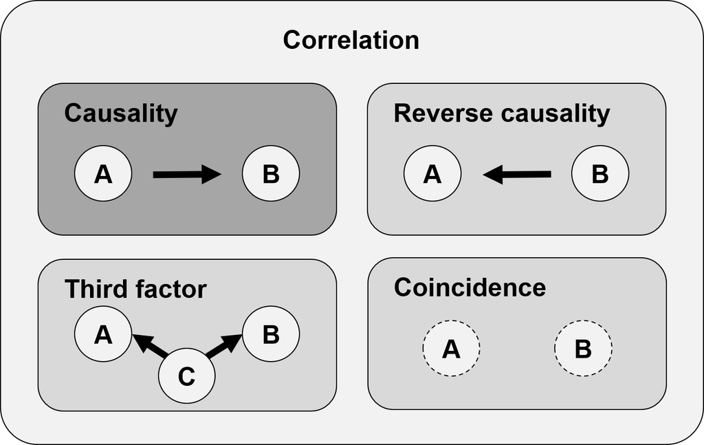

### 0.2. データの種類 (データの性質)

社会科学のデータには、**実験データ**と**非実験データ(観察データ)**の2種類がある。

1. **実験データ**
- 処置や政策の評価・因果効果のためにデザインされた実験から得られるデータ (非常に理想的)
- 処置以外の他のすべての要因が (平均的に) 等しいグループをつくる ($E[ \epsilon |X] = 0$)  
  例）ランダム化比較試験 (RCT: randomized controlled trial)
2. **非実験データ**
- 人間の実際の行動や社会経済を対象としたデータ (ほとんどこっち)
- 処置の有無が処置以外の要因と関連 ($E[ \epsilon |X] \neq 0$)  
  例）国勢調査, GDP

[figure not shown]

## 1. 多次元のデータ

### 1.1. データの種類 (データの構造)

社会科学のデータには、**横断的データ (cross-section data)**と**時系列データ (time-series data)**、またそれらを合わせた**パネルデータ (panel data)**の3種類がある。

1. **クロスセクションデータ**
- 一時点の異なる観測体に関するデータ  
  例) 政府の家計調査, 国際比較調査
- $Y_i = \beta_0 + \beta_0 X_i + \beta_2 C_i + \epsilon_i$  
  ただし、$i$は個体を表す (e.g. 個人, 企業, 国)
2. **時系列データ**
- 同じ観測体の異時点のデータ  
  例) ある企業の株価, ある1国のGDP
- $Y_t = \beta_0 + \beta_0 X_t + \beta_2 C_t + \epsilon_t$  
  ただし、$t$は時間を表す (e.g. 秒, 分, 時, 日, 週, 月, 年)
3. **パネルデータ**
- 複数の観測体の複数時点のデータ
- 異時間店と異観測体間という二次元のデータの差分(variation)を持つ  
  例) ある企業の株価, ある1国のGDP
- $Y_{it} = \beta_0 + \beta_0 X_{it} + \beta_2 C_{it} + \epsilon_{it}$

[figure not shown]

#### **時系列データの分類**

|  | 時系列データ (Time Series Data) | 繰り返しクロスセクション (Repeated Cross-section Data) | パネルデータ (Panel Data) |
| --- | --- | --- | --- |
| 複数期間 (time-series) | X | X | X |
| 横断的データ (cross-section) |  | X | X |
| 同じ観測隊の追跡 (longitudinal) | X |  | X |

#### **データテーブル構造**

1. **ロングフォーム** (ソフトウェアを使ってパネル分析をする際の形式)

| ID ($i$) | Year ($t$) | $y$ | $X$ | $Z$ |
| --- | --- | --- | --- | --- |
| 1 | 2000 | $y_{1,2000}$ | $X_{1,2000}$ | $Z_{1,2000}$ |
| 1 | 2005 | $y_{1,2005}$ | $X_{1,2005}$ | $Z_{1,2005}$ |
| 1 | 2010 | $y_{1,2010}$ | $X_{1,2010}$ | $Z_{1,2010}$ |
| 2 | 2000 | $y_{2,2000}$ | $X_{2,2000}$ | $Z_{2,2000}$ |
| 2 | 2005 | $y_{2,2005}$ | $X_{2,2005}$ | $Z_{2,2005}$ |
| 2 | 2010 | $y_{2,2010}$ | $X_{2,2010}$ | $Z_{2,2010}$ |
| 3 | 2000 | $y_{3,2000}$ | $X_{3,2000}$ | $Z_{3,2000}$ |
| 3 | 2005 | $y_{3,2005}$ | $X_{3,2005}$ | $Z_{3,2005}$ |
| 3 | 2010 | $y_{3,2010}$ | $X_{3,2010}$ | $Z_{3,2010}$ |

2. **ワイドフォーム** (人間が見やすい形式)

| ID ($i$) | $y_{2000}$ | $y_{2005}$ | $y_{2010}$ | $X_{2000}$ | $X_{2005}$ | $X_{2010}$ |
| --- | --- | --- | --- | --- | --- | --- |
| 1 | $y_{1,2000}$ | $y_{1,2005}$ | $y_{1,2010}$ | $X_{1,2000}$ | $X_{1,2005}$ | $X_{1,2010}$ |
| 2 | $y_{2,2000}$ | $y_{2,2005}$ | $y_{2,2010}$ | $X_{2,2000}$ | $X_{2,2005}$ | $X_{2,2010}$ |
| 3 | $y_{3,2000}$ | $y_{3,2005}$ | $y_{3,2010}$ | $X_{3,2000}$ | $X_{3,2005}$ | $X_{3,2010}$ |

### 1.2. 多次元データの有用性

例) 最低賃金規制が雇用に与える効果 ([Card-Krueger, AER, 1994](https://www.jstor.org/stable/2118030))

#### 理論モデル: **<ミクロ経済学>の教科書**

最低賃金の上昇は、低賃金労働者に依存するような産業の雇用を減少させる。

#### 実証モデルa: **時系列** (=因果推定二バイアスを含む実証モデル)

$$E_t = \beta_0 + \beta_1 MW_t + \beta_2 Z_t + \epsilon_t$$

- $t$: 期間 (e.g. 2000, 2005, 2010)
- $E$: 雇用レベル (e.g. 雇用率)
- $MW$: 最低賃金レベル (e.g. 10 USD/hr.)
- $Z$: 制御変数 (e.g. 実質GDP, 産業の売上高)

<問題点>

- 最低賃金に加え、雇用環境も**異時点間**で変化する
- 雇用環境を表すすべての変数を制御することは困難  
  → 最低賃金と雇用環境の影響を分離することが困難  
  例) ファーストフード業界の激化, 非正規雇用の増加, 法規制の変化

$$E_t = \beta_0 + \beta_1 MW_t + \beta_2 Z_t + U_t + \epsilon_t$$

$\Longrightarrow$ **欠落変数バイアス**が生じる

[figure not shown]

#### 実証モデルb: **クロスセクション** (=因果推定にバイアスを含む実証モデル)

$$E_i = \beta_0 + \beta_1 MW_i + \beta_2 Z_i + \epsilon_i$$

- $i$: 地点 (e.g. 州, 市)
- $E$: 雇用レベル (e.g. 雇用率)
- $MW$: 最低賃金レベル (e.g. 10 USD/hr.)
- $Z$: 制御変数 (e.g. 実質GDP, 産業の売上高)

<問題点>

- 最低賃金に加え、雇用環境も**異地点間**で変化する
- 雇用環境を表すすべての変数を制御することは困難  
  → 最低賃金と雇用環境の影響を分離することが困難  
  例) 地点間でファーストフード業界の競争の激しさが異なる, 非正規雇用の増加, 法規制の変化

$$E_i = \beta_0 + \beta_1 MW_i + \beta_2 Z_i + U_i + \epsilon_i$$
$\Longrightarrow$ **欠落変数バイアス**が生じる

[figure not shown]

#### 実証モデルc: **多次元データ** (=異時点間と異地点間のバイアスに対処した実証分析)

[figure not shown]

Card-Krueger (AER, 1994) 論文

- Title: Minimum Wages and Employment: A Case Study of the Fast-Food Industry in New Jersey and Pennsylvania
- [Card and Krueger (AER, 1994)](https://www.jstor.org/stable/2118030)
- [Card and Krueger (AER, 2000, reply)](https://www.jstor.org/stable/2677856?seq=1#metadata_info_tab_contents)
- [データセット](https://davidcard.berkeley.edu/data_sets.html)

概要

- 1992年4月1日に、NJ州が最低賃金を、`$4.25 USD/hr.` から `5.05 USD/hr.` に引き上げ。
- 近隣のPA州は、同時期に最低賃金の引き上げを据え置き。
- この2州の差を利用して、最低賃金がファーストフードのチェーン店の雇用状況に与える影響を調査。

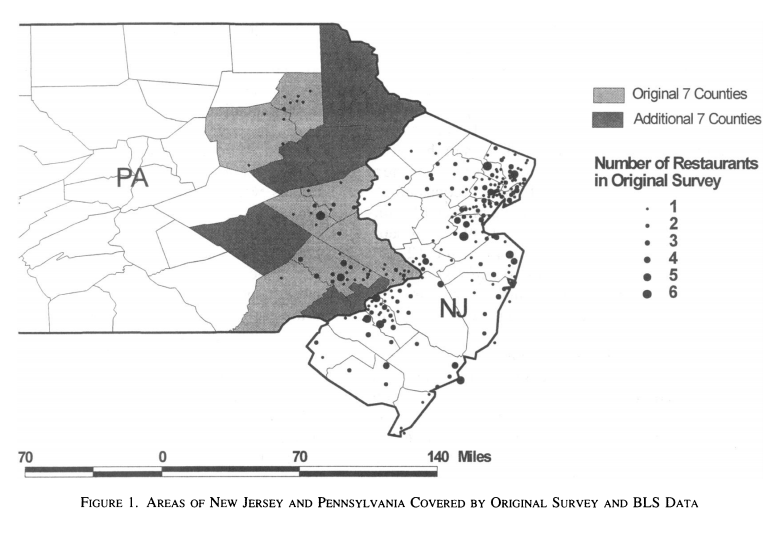

Fig.1 of Card-Krueger (AER, 2000, *reply*)

- NJ州全域と境界線に近いPA州の一部からデータを抽出。
- *Reply*の論文では、PA州のサンプルが増加。

[figure not shown]

Fig.1 of Card-Krueger (AER, 1994)

- 最低賃金引き上げ前(1992年 2月)は、両者の最低賃金の分布は似ている
- 最低賃金引き上げ後(1992年11月)は、NJ州には`5.05 USD/hr.`未満の最低賃金の店舗は存在しなくなる

#### **ヒストグラムを描く**

```
#--- Stata ver. ---#
hist wage_st0, by(state)
hist wage_st1, by(state)
```

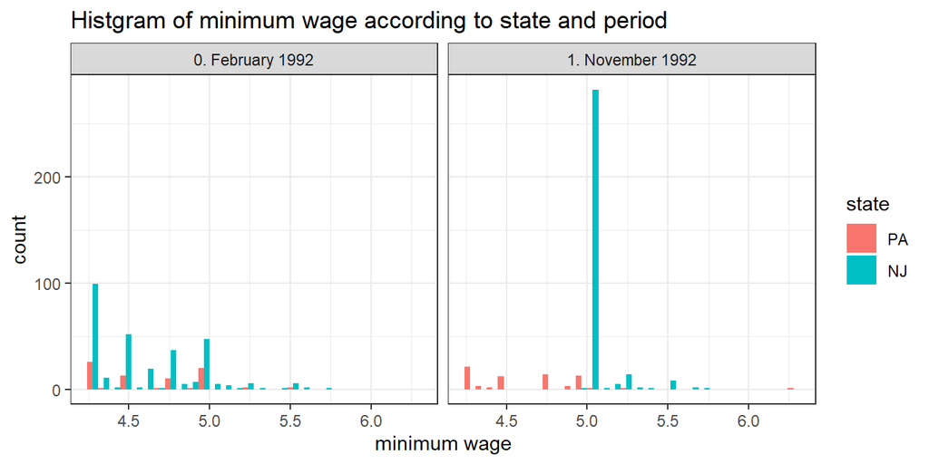

```r
#--- R ver. ---#

df %>%
  #-- convert to long-form --#
  pivot_longer(cols = starts_with("wage"), names_to = "period", values_to = "wage") %>%
  mutate(
    period = case_when(
      period == "wage_st0" ~ "0. February 1992",
      period == "wage_st1" ~ "1. November 1992"
    )
  ) %>%
  #-- ggplot --#
  ggplot(aes(x = wage, fill = state)) +
  geom_histogram(position = "dodge") +
  facet_grid(. ~ period) +
  ggtitle("Histgram of minimum wage according to state and period") +
  xlab("minimum wage") + labs(fill = "state") +
  theme_bw()
```

## 2. 差分の差分法 (DID: Difference-in-Difference)

### 2.1. DIDの概念

**Table**

|  | 対照群 (Control group $D_0$) |  | 処置群 (Treatment group $D_1$) |  | 異地点間の変化 |
| --- | --- | --- | --- | --- | --- |
| 対照群 (政策介入前 $T_0$) | $\overline{雇用}_{PA, Before}$ | $-$ | $\overline{雇用}_{NJ, Before}$ | $=$ | Bias(地点) |
| 処置群 (政策介入後 $T_1$) | $\overline{雇用}_{PA, After}$ | $-$ | $\overline{雇用}_{NJ, After}$ | $=$ | 政策効果 $+$ Bias(地点) |
| 異時点間の変化 | Bias(時間) | $-$ | 政策効果 $+$ Bias(時間) | $=$ | **政策効果** |

**Figure**

[figure not shown]

#### **DIDの利点 (1)**

- 実験データではないので、`NJ州`と`PA州`には個体差が存在する。  
  しかし、2回の差分を取ることで、**観測できない変数(unobservable)**による異時点間と異地点間のバイアスの双方を制御できる。

#### **実際の推定結果**

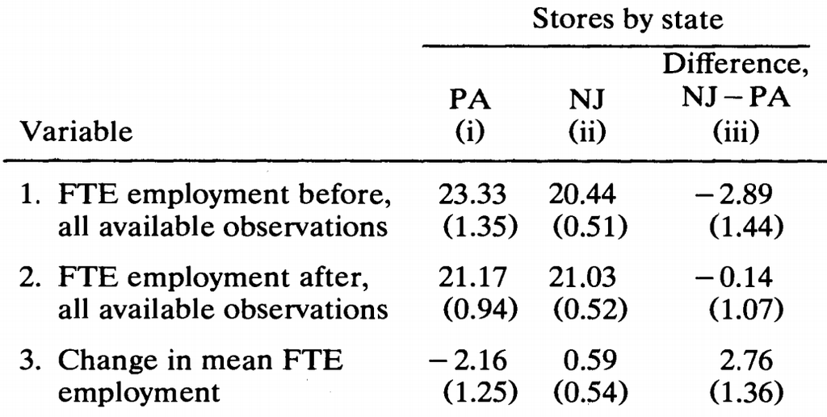

Table 3 of Card-Krueger (AER, 1994)

- 最低賃金の上昇が低賃金労働者に依存するような産業の雇用に与える因果効果は、`2.76`.
- ただし、ミクロ経済学の理論モデルでは、$マイナス$になるべき。

### 2.2. DIDの他の利点

#### **DIDの利点 (2)**

実際に取られた政策・ビジネス戦略・自然災害などを自然実験 (natural experiment) として利用した**準実験(Qausi-experimental)手法**

2-a. 教室・ラボ実験に比べて効果が行おり現実的  
(経済主体が実社会においてどのように反応するかを見ることができる)

2-b. 明確な処置群(介入のあったグループ)と対照群(介入のなかったグループ)の処置前後を利用  
→ 平均値さえあれば、効果推定が可能

2-c. パネルデータである必要はなく、繰り返しクロスセクションデータでも良い  
例) 処置前後に異なるサンプルを無作為抽出しても良い

#### **DIDの利点 (3)**

重回帰分析をそのまま適用できる

$$Y_{it} = \alpha + \beta D_i + \gamma T_t + \delta (D_i \times T_t) + \epsilon_{it}$$

- $i$: 観測主体を表す添え字
- $t$: 観測期間を表す添え字
- $Y$: 政策効果の結果を表す変数
- $D={0,1}$: $i$が処置群か否かを表す変数
- $T={0,1}$: $t$が処置期間か否かを表す変数

$\Longrightarrow$ 係数$\delta$: 政策効果  
$\Longrightarrow$ 係数$\delta$の標準誤差: 政策効果の標準誤差  
$\Longrightarrow$ 係数$\delta$のt検定: 政策効果の有無

|  | 対照群 (Control group $D_0$) |  | 処置群 (Treatment group $D_1$) |  | 異地点間の変化 |
| --- | --- | --- | --- | --- | --- |
| 対照群 (政策介入前 $T_0$) | $\alpha$ ($D=0$, $T=0$) | $-$ | $\alpha + \beta$ ($D=1$, $T=0$) | $=$ | $\beta$ |
| 処置群 (政策介入後 $T_1$) | $\alpha+ \gamma$ ($D=0$, $T=1$) | $-$ | $\alpha + \beta + \gamma + \delta$ ($D=1$, $T=1$) | $=$ | $\beta + \delta$ |
| 異時点間の変化 | $\gamma$ | $-$ | $\gamma + \delta$ | $=$ | $\delta$ |

[figure not shown]

1. 対照群の差分 ($D=0$)
- $D=0$, $T=0$

$$Y_{D_i=0,T_i=0} = \alpha \quad (+ \epsilon)$$

```r
alpha = mean(df$fte0[df$state == "PA"], na.rm = TRUE)
```

$\alpha=$ 23.3311688

- $D=0$, $T=1$

$$Y_{D_i=0,T_i=1} = \alpha + \gamma \quad (+ \epsilon)$$

```r
alpha_gamma = mean(df$fte1[df$state == "PA"], na.rm = TRUE)
```

$\alpha+\gamma=$ 21.1655844

- $\Delta Y_{D_i=0}$

$$\Delta Y_{D_i=0} = \gamma \quad (+ \epsilon)$$

```r
gamma = alpha_gamma - alpha
```

$\gamma=$ -2.1655844

2. 処置群の差分 ($D=1$)
- $D=1$, $T=0$

$$Y_{D_i=1,T_i=0} = \alpha + \beta \quad(+ \epsilon)$$

```r
alpha_beta = mean(df$fte0[df$state == "NJ"], na.rm = TRUE)
```

$\alpha+\gamma=$ 20.4455696

- $D=1$, $T=1$

$$Y_{D_i=1,T_i=1} = \alpha + \beta + \gamma + \delta \quad (+ \epsilon)$$

```r
alpha_beta_gamma_delta = mean(df$fte1[df$state == "NJ"], na.rm = TRUE)
```

$\alpha+\gamma=$ 21.0274295

- $\Delta Y_{D_i=1}$

$$\Delta Y_{D_i=1} = \gamma + \delta \quad (+ \epsilon)$$

```r
gamma_delta = alpha_beta_gamma_delta - alpha_beta
```

$\alpha+\gamma=$ 0.5818598

3. 処置群の差分と対照群の差分の差分
- $\Delta Y_{D_1=0} - \Delta Y_{D_i=0}$

$$\Delta Y_{D_1=0} - \Delta Y_{D_i=0} = \delta$$

```r
delta = gamma_delta - gamma
```

$\alpha+\gamma=$ 2.7474443

**より厳密に** (誤差項を考慮する)

- 一階差分

$$\begin{align}
\Delta Y_{D_i=0} &= E[Y_{it} | D_i = 0, T_t = 1] - E[Y_{it} | D_i = 0, T_t = 0] \\
&= \gamma + E[\epsilon_{it} | D_i = 0, T_t = 1] - E[\epsilon_{it} | D_i = 0, T_t = 0] \\\\
\Delta Y_{D_i=1} &= E[Y_{it} | D_i = 1, T_t = 1] - E[Y_{it} | D_i = 1, T_t = 0] \\
&= \gamma + \delta + E[\epsilon_{it} | D_i = 1, T_t = 1] - E[\epsilon_{it} | D_i = 1, T_t = 0]
\end{align}$$

- 二階差分

$$\begin{align}
\Delta Y_{D_i=1} - \Delta Y_{D_i=0} &= \delta \\
&+ (E[\epsilon_{it} | D_i = 1, T_t = 1] - E[\epsilon_{it} | D_i = 1, T_t = 0]) \\
&- (E[\epsilon_{it} | D_i = 0, T_t = 1] - E[\epsilon_{it} | D_i = 0, T_t = 0])
\end{align}$$

### 2.3. 平行トレンド仮定

DIDが因果効果を推定するためには、以下の仮定を満たす必要がある。  
この仮定を**平行トレンド仮定 (parallel trend assumption)**という。

$$(E[\epsilon_{it} | D_i = 1, T_t = 1] - E[\epsilon_{it} | D_i = 1, T_t = 0]) =
(E[\epsilon_{it} | D_i = 0, T_t = 1] - E[\epsilon_{it} | D_i = 0, T_t = 0])$$

$$E[\epsilon_{NJ, After} - \epsilon_{NJ, before}] = [\epsilon_{PA, After} - \epsilon_{PA, before}]$$

#### **平行トレンドの確認**

1. <視覚的> 処置群と対照群の$Y$の平均値をプロットする

[figure not shown]

2. <統計的> 処置の瞬間($t=0$)と処置前($t=-1$)の処置効果($\delta_s$)を推定し、$\delta_s =0$を確認する

$$Y_{it} = \alpha + \beta D_i + \gamma T_t + \ \sum_{s=-q}^{-1} \delta_s (D_i \times T_t) + \epsilon_{it}$$

$\Longrightarrow$ 処置前に平行トレンドが成立していれば、$\delta_s = 0$となる。  
しかし、$\delta_s = 0$であっても、処置期間中の平行トレンドが成立していることの証明にはならない。

### 2.4. 弱仮定 (不偏推定量)

平行トレンドを満たさないときの対処法

$$Y_{it} = \alpha + \beta D_i + \gamma T_t + \delta (D_i \times T_t) + \theta Z_{it} + \epsilon_{it}$$

- 平均独立の仮定 (強い仮定)

$$E[\epsilon | Z_{it}]= 0 \quad \quad for \quad all \quad i,t$$

- 条件付き平均トレンドの仮定 (弱い仮定)

$$E[\epsilon_{i,t+1} - \epsilon_{i,t} | D_i = 1, Z_{it}] = E[\epsilon_{i,t+1} - \epsilon_{i,t} | D_i = 0, Z_{it}]$$

### 2.5. 平行トレンドが成り立たないとき

Q. 平行トレンドの過程が成り立たない可能性がある場合とは？

A. 処置群と対照群の振り分けが、**対象者自身**が選択される場合。

- ケース1 「教育プログラムに参加したい」$b/c$「学習意欲が高い」$\rightarrow$「もともと勉強が得意」

$$E[\epsilon_{i,1} - \epsilon_{i,0} | D_i = 1] > E[\epsilon_{i,1} - \epsilon_{i,0} | D_i = 0] \Longrightarrow 上方バイアス$$

- ケース2 「教育プログラムに参加したい」$b/c$「満足な教育が得られていない (家庭環境が悪い)」$\rightarrow$「もともと勉強が苦手」

$$E[\epsilon_{i,1} - \epsilon_{i,0} | D_i = 1] < E[\epsilon_{i,1} - \epsilon_{i,0} | D_i = 0] \Longrightarrow 下方バイアス$$

### 2.6. DIDの説得力を高める方法

1. 政策介入の無作為性  
   処置群と対照群を上手に選ぶ
2. 平行トレンドを確認する。
   1. 処置群と対照群の被説明変数の時系列データをプロットする
   2. 処置前のデータでDIDをして、$\delta_s=0$を確認する
3. パネルデータである場合、固定効果(fixed effect)を入れて異質性を制御する
4. 観測可能な制御変数を入れる
5. 偽の処置群と対照群を設定し、統計的有意性が小さくなることを確認する (robustness check)
6. 三重差分(DDD: Difference-in-Difference-in-Difference)  
   処置群と対照群の中にもう1つの処置群と対照群を見つけて、三重差分をとる  
   参考：『岩波データサイエンス vol.3 (因果推論)』[補論 差の差法の拡張：三重差分](https://sites.google.com/site/iwanamidatascience/vol-3/vol3-ingasuiron/vol3-yamaguchi)

#### **固定効果**

1. **差分モデル** ($T$が2期間の場合のみ)
- $\epsilon_{it}$を、観測不可能な個体間の異質性$A_{it}$と観測不可能なその他の異質性$u_{it}$に分解する。

$$Y_{it} = \alpha + \beta D_i + \gamma T_t + \delta(D_i \times T_t) + A_{it} + u_{it}$$

- 一階差分をとることで、観測不可能な個体間の異質性$A_{it}$を制御できる。

$$\begin{align}
Y_{i0} &= \alpha + \beta D_i + A_{i0} + u_{i0} \\
Y_{i1} &= \alpha + \beta D_i + \gamma + \delta D_i + A_{i1} + u_{i1}
\end{align}$$

- $Y_{i1}$と$Y_{i0}$の差分をとる。

$$\begin{align}
Y_{i1} - Y_{i0} &= \gamma + \delta D_i + (A_{i1}-A_{i0}) + (u_{i1}-u_{i0}) \\
\Delta Y_{it} &= \gamma + \delta D_i + \Delta A_{it} + \Delta u_{it} \\
\end{align}$$

- $A_{it}$が時間を通して時間不変(time-invariant)である場合、$A_{i0}=A_{i1}=A_{i}$より$\Delta A_{it}=0$となるため、

$$\Delta Y_{it} = \gamma + \delta D_i + \Delta u_{it}$$

2. **平均除去 (demeaned)**; **最小二乗ダミー変数推定 (LSDV: least square dummy variables)**
- $\epsilon_{it}$を、観測不可能な時間不変の個体効果$\mu_{i}$と観測不可能なその他の異質性$u_{it}$に分解する。

$$y_{it} = \beta X_{it} + \mu_i + v_{it}$$

- 各個体ごとに変数の平均値をとる。

$$\bar{y}_{i} = \beta \bar{X}_{i} + \mu_i + \bar{v}_{i}$$

- 元の式から平均値をとった式を引く

$$y_{it} - \bar{y}_{i} = \beta (X_it - \bar{X}_{i}) + (v_{it} - \bar{v}_{i})$$

- 上記の式をOLS推定することにより、最良不偏推定量$\bar{\beta}$を得る。  
  また、固定効果は以下のようになる。

$$\bar{\mu}_i = \bar{y}_i - \bar{\beta}_i \bar{x}_i$$

#### **制御変数**

**差分モデル**において、$A_{i1}$が時間を通して時間可変(time-variant)の場合、$cov(D_i, \Delta A_{it}) \neq 0$となり、内生性バイアスが生じる。  
→ $\Delta A_{it} \approx \theta Z_i$となるような、制御変数を加える必要がある。

$$\Delta Y_{it} = \gamma + \delta D_i + \theta Z_i + \Delta u_{it}$$

## 3. DIDの演習

### 3.1. t検定

```
#--- Stata ver. ---#

* 時間軸の差分 (表の列方向)
ttest fte0 == fte1 if state == 0 /* PA */
ttest fte0 == fte1 if state == 1 /* NJ */

* 個体間の差分 (表の縦方向)
ttest fte0, by(state) unequal
ttest fte1, by(state) unequal
```

```r
#--- R ver. ---#

# 時間軸の差分 (表の列方向)
t.test(df$fte0[df$state == "PA"], df$fte1[df$state == "PA"], paired = TRUE)
t.test(df$fte0[df$state == "NJ"], df$fte1[df$state == "NJ"], paired = TRUE)

# 個体間の差分 (表の縦方向)
t.test(df$fte0[df$state == "PA"], df$fte0[df$state == "NJ"])
t.test(df$fte1[df$state == "PA"], df$fte1[df$state == "NJ"])
```

```
##
##  Paired t-test
##
## data:  df$fte0[df$state == "PA"] and df$fte1[df$state == "PA"]
## t = 1.8219, df = 74, p-value = 0.07251
## alternative hypothesis: true difference in means is not equal to 0
## 95 percent confidence interval:
##  -0.2138597  4.7805263
## sample estimates:
## mean of the differences
##                2.283333
##
##
##  Paired t-test
##
## data:  df$fte0[df$state == "NJ"] and df$fte1[df$state == "NJ"]
## t = -0.97055, df = 308, p-value = 0.3325
## alternative hypothesis: true difference in means is not equal to 0
## 95 percent confidence interval:
##  -1.4127911  0.4794578
## sample estimates:
## mean of the differences
##              -0.4666667
##
##
##  Welch Two Sample t-test
##
## data:  df$fte0[df$state == "PA"] and df$fte0[df$state == "NJ"]
## t = 1.9959, df = 99.129, p-value = 0.04869
## alternative hypothesis: true difference in means is not equal to 0
## 95 percent confidence interval:
##  0.01692441 5.75427402
## sample estimates:
## mean of x mean of y
##  23.33117  20.44557
##
##
##  Welch Two Sample t-test
##
## data:  df$fte1[df$state == "PA"] and df$fte1[df$state == "NJ"]
## t = 0.12825, df = 126.49, p-value = 0.8982
## alternative hypothesis: true difference in means is not equal to 0
## 95 percent confidence interval:
##  -1.993538  2.269848
## sample estimates:
## mean of x mean of y
##  21.16558  21.02743
```

### 3.2. DID回帰

#### データフレームの成形

- 現在のデータフレーム(`df`)は、**ワイドフォーム**。 `fte0`と`fte1`が別々の列を持っている。
- StataやRでの分析のためには、**ロングフォーム**に直す必要がある。

```
#--- Stata ver. ---#
help reshape
reshape long fte wage_st, i(sheet) j(period)
```

```r
#--- R ver. ---#

df_long <- df %>%
  pivot_longer(cols = starts_with("fte"), names_to = "period", values_to = "fte") %>%
  mutate(period =
    case_when(
      period == "fte0" ~ 0,
      period == "fte1" ~ 1
    ) %>% as.integer()
  )

df_long
```

```
## # A tibble: 810 x 8
##    sheet chain co_owned state wage_st0 wage_st1 period   fte
##    <int> <int>    <int> <fct>    <dbl>    <dbl>  <int> <dbl>
##  1     1     1        0 NJ        4.5      5.05      0  35
##  2     1     1        0 NJ        4.5      5.05      1  44
##  3     2     1        0 NJ        4.75     5.25      0  16
##  4     2     1        0 NJ        4.75     5.25      1  15.5
##  5     3     2        0 NJ        4.25     5.05      0  15.5
##  6     3     2        0 NJ        4.25     5.05      1  10.5
##  7     4     3        0 NJ        4.75     5.05      0  19
##  8     4     3        0 NJ        4.75     5.05      1  24
##  9     5     3        0 NJ        4.5      5.15      0  24
## 10     5     3        0 NJ        4.5      5.15      1  29
## # ... with 800 more rows
```

#### 回帰分析

```
#--- Stata ver. ---#

* basic
gen state_period = state*period
reg fte state period state_period

* short cut
reg fte state period state_period
```

```r
did = lm(fte ~ state + period + state*period, data = df_long)
summary(did)
```

```
##
## Call:
## lm(formula = fte ~ state + period + state * period, data = df_long)
##
## Residuals:
##     Min      1Q  Median      3Q     Max
## -21.166  -6.446  -1.027   4.473  64.554
##
## Coefficients:
##                Estimate Std. Error t value Pr(>|t|)
## (Intercept)      23.331      1.074  21.728   <2e-16 ***
## stateNJ          -2.886      1.197  -2.410   0.0162 *
## period           -2.166      1.519  -1.426   0.1542
## stateNJ:period    2.747      1.693   1.623   0.1050
## ---
## Signif. codes:  0 '***' 0.001 '**' 0.01 '*' 0.05 '.' 0.1 ' ' 1
##
## Residual standard error: 9.423 on 785 degrees of freedom
##   (21 observations deleted due to missingness)
## Multiple R-squared:  0.007365,   Adjusted R-squared:  0.003571
## F-statistic: 1.941 on 3 and 785 DF,  p-value: 0.1214
```

### 3.3. DID回帰 (first differenced)

#### データフレームの成形

- 現在のStataのデータフレーム(`df`)は、**ロングフォーム**。
- `fte`のFirst difference をとるために、**ワイドフォーム**に直す必要がある。

```
#--- Stata ver. ---#

* `state_period`をドロップする
drop state_period

* ロングフォームからワイドフォームへ
reshape wide fte wage_st, i(sheet) j(period)

* `fte`の差分をとる
gen diff_fte = fte1 - fte0
```

```r
#--- R ver. ---#
df <- df %>%
  mutate(diff_fte = fte1 - fte0)
```

#### 回帰分析

```
#--- Stata ver. ---#
reg diff_fte state
```

```r
did_first_diff <- lm(diff_fte ~ state, data = df)
summary(did_first_diff)
```

```
##
## Call:
## lm(formula = diff_fte ~ state, data = df)
##
## Residuals:
##     Min      1Q  Median      3Q     Max
## -39.217  -3.967   0.533   4.533  33.533
##
## Coefficients:
##             Estimate Std. Error t value Pr(>|t|)
## (Intercept)   -2.283      1.036  -2.205   0.0280 *
## stateNJ        2.750      1.154   2.382   0.0177 *
## ---
## Signif. codes:  0 '***' 0.001 '**' 0.01 '*' 0.05 '.' 0.1 ' ' 1
##
## Residual standard error: 8.968 on 382 degrees of freedom
##   (21 observations deleted due to missingness)
## Multiple R-squared:  0.01464,    Adjusted R-squared:  0.01206
## F-statistic: 5.675 on 1 and 382 DF,  p-value: 0.01769
```

#### 回帰分析 (コントロール変数つき)

```
#--- Stata ver. ---#
reg diff_fte state i.chain i.co_own
```

```r
did_first_diff_z <- lm(diff_fte ~ state + factor(chain) + factor(co_owned), data = df)
summary(did_first_diff_z)
```

```
##
## Call:
## lm(formula = diff_fte ~ state + factor(chain) + factor(co_owned),
##     data = df)
##
## Residuals:
##     Min      1Q  Median      3Q     Max
## -39.672  -3.957   0.440   4.275  33.234
##
## Coefficients:
##                   Estimate Std. Error t value Pr(>|t|)
## (Intercept)        -1.8277     1.1729  -1.558   0.1200
## stateNJ             2.7846     1.1556   2.410   0.0164 *
## factor(chain)2      0.2408     1.2772   0.189   0.8506
## factor(chain)3     -2.5884     1.2985  -1.993   0.0469 *
## factor(chain)4     -0.1910     1.4311  -0.133   0.8939
## factor(co_owned)1   0.3625     1.0817   0.335   0.7377
## ---
## Signif. codes:  0 '***' 0.001 '**' 0.01 '*' 0.05 '.' 0.1 ' ' 1
##
## Residual standard error: 8.949 on 378 degrees of freedom
##   (21 observations deleted due to missingness)
## Multiple R-squared:  0.02904,    Adjusted R-squared:  0.01619
## F-statistic: 2.261 on 5 and 378 DF,  p-value: 0.04789
```